# Lecture 15: K-Means Clustering

from

> https://github.com/UBC-CS/cpsc330

## Introduction to unsupervised learning

### Types of machine learning

Recall the typical learning problems we discussed.

- Supervised learning ([Gmail spam filtering](https://support.google.com/a/answer/2368132?hl=en))
  - Training a model from input data and its corresponding targets to predict targets for new examples.
- **Unsupervised learning** (this course) ([Google News](https://news.google.com/))
  - Training a model to find patterns in a dataset, typically an unlabeled dataset.
- Reinforcement learning ([AlphaGo](https://deepmind.com/research/case-studies/alphago-the-story-so-far))
  - A family of algorithms for finding suitable actions to take in a given situation in order to maximize a reward.
- **Recommendation systems** ([Amazon item recommendation system](https://www.cs.umd.edu/~samir/498/Amazon-Recommendations.pdf))
  - Predict the "rating" or "preference" a user would give to an item.

### Supervised learning

- Training data comprises a set of observations ($X$) and their corresponding targets ($y$).
- We wish to find a model function $f$ that relates $X$ to $y$.
- Then use that model function to predict the targets of new examples.
- We have been working with this set up so far.

[figure not shown]

### Unsupervised learning

- Training data consists of observations ($X$) without any corresponding targets.
- Unsupervised learning could be used to group similar things together in $X$ or to find underlying structure in the data.

[figure not shown]

### Can we learn without targets?

- Yes, but the learning will be focused on finding the underlying structures of the inputs themselves (rather than finding the function $f$ between input and output like we did in supervised learning models).
- Examples:
  - Clustering
  - Dimensionality reduction

### Labeled vs. Unlabeled data

- If you have access to labeled training data, you're in the "supervised" setting.
- You know what to do in that case.
- Unfortunately, getting large amount of labeled training data is often time consuming and expensive.
- Annotated data can become "stale" after a while in cases such as fraud detection.
- Can you still make sense of the data even though you do not have the labels?
- Yes! At least to a certain extent!

### Example: Supervised vs unsupervised learning

- In supervised learning, we are given features $X$ and target $y$.

| **Dataset 1** |  |  |
| --- | --- | --- |
| $x_1$ | $y$ |  |
| 101.0 | Sick |  |
| 98.5 | Not Sick |  |
| 93.8 | Sick |  |
| 104.3 | Sick |  |
| 98.6 | Not Sick |  |

| **Dataset2** |  |  |  |
| --- | --- | --- | --- |
| $x_1$ | $x_2$ | $y$ |  |
| -2.68 | 0.32 | class 1 |  |
| -2.71 | -0.18 | class 1 |  |
| 1.28 | 0.69 | class 2 |  |
| 0.93 | 0.32 | class 2 |  |
| 1.39 | -0.28 | class 3 |  |

- In unsupervised learning, we are only given features $X$.

| **Dataset 1** |  |  |
| --- | --- | --- |
| $x_1$ |  |  |
| 101.0 |  |  |
| 98.5 |  |  |
| 93.8 |  |  |
| 104.3 |  |  |
| 98.6 |  |  |

| **Dataset 2** |  |  |  |
| --- | --- | --- | --- |
| $x_1$ | $x_2$ |  |  |
| -2.68 | 0.32 |  |  |
| -2.71 | -0.18 |  |  |
| 1.28 | 0.69 |  |  |
| 0.93 | 0.32 |  |  |
| 1.39 | -0.28 |  |  |

## Clustering motivation

### [Clustering activity](https://docs.google.com/document/d/1hgkyxxvir-WddFhzuO6pRWjGnItEODbjFi-VUsIjYCk/edit?usp=sharing)

- Suppose you are asked to categorize the items below. What groups would you identify?

[figure not shown]

Source: Images taken from different recipe sites on the internet.

- If you want to build a machine learning model to cluster such images how would you represent such images?
- Imagine that we also have ratings data of food items and users for a large number of users. Can you exploit the power of community to recommend certain food items to a given user they are likely to consume?

### Why clustering?

- Most of the data out there is unlabeled.
- Getting labeled training data is often difficult, expensive, or simply impossible in some cases.
- Can we extract some useful information from unlabeled data?
- The most intuitive way is to group similar examples together to get some insight into the data even though we do not have the targets.

### Clustering

**Clustering** is the task of partitioning the dataset into groups called clusters.

The goal of clustering is to discover underlying groups in a given dataset such that:

- examples in the same group are as similar as possible;
- examples in different groups are as different as possible.

### Input and possible output

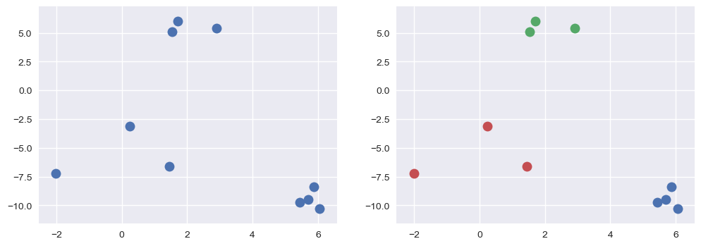

```python
X, y = make_blobs(n_samples=10, centers=3, n_features=2, random_state=10)
fig, axes = plt.subplots(1, 2, figsize=(12, 4))
mglearn.discrete_scatter(X[:, 0], X[:, 1], markers="o", ax=axes[0])
mglearn.discrete_scatter(X[:, 0], X[:, 1], y, markers="o", ax=axes[1]);
```

Think of clustering as colouring the points (e.g., blue, red, green) such that points with the same color are close to each other.

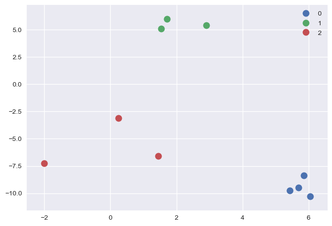

```python
mglearn.discrete_scatter(X[:, 0], X[:, 1], y, markers="o")
plt.legend();
```

- Usually the clusters are identified by a **cluster label**.
- These labels are arbitrary, and relabeling the points (label switching) does not make a difference.
- What we care about is which points have the same labels and which ones have different labels.

### Is there a notion of "correct" grouping?

- Very often we do not know how many clusters are there in the data or if there are any clusters at all. In real-world data, clusters are rarely as clear as in our toy example above.
- There is a notion of coherent and optimal (in some sense) clusters but there is no absolute truth here.

### Example 1

Which of the following grouping of emoticons is the "correct" grouping?

[figure not shown]

Both seem reasonable!

### Example 2

How would you group a deck of cards?

- In a deck of cards:
  1. We have two colors: black and red;
  2. We have four suits: Clubs, Spades, Hearts, and Diamonds;
  3. We have 13 values: $\left\{A,2,3,4,5,6,7,8,9,10,J,Q,K\right\}$.
- What are the "true" clusters here?

Should we cluster by suits: Clubs, Spades, Hearts, and Diamonds?

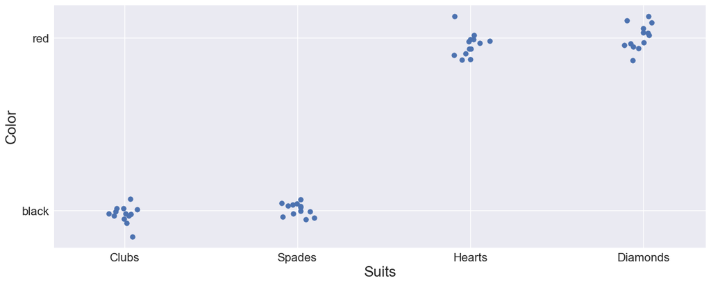

```python
plot_deck(group_by="suits", w=16, h=6)
```

Should we cluster by colors?

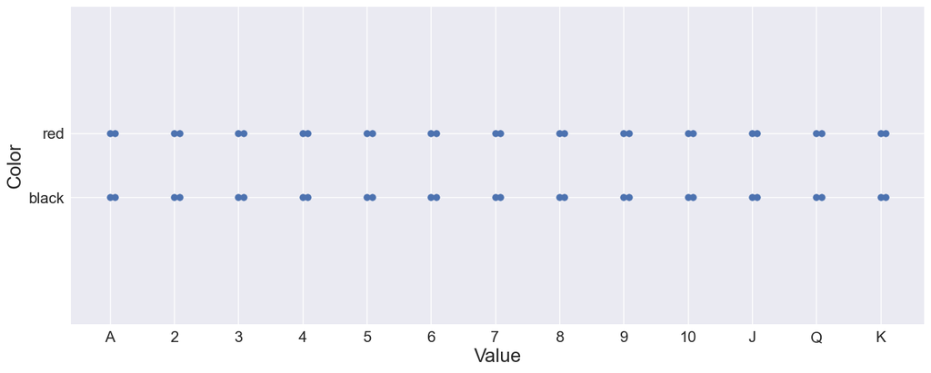

```python
plot_deck(group_by="color", w=16, h=6)
```

Should we cluster by value?

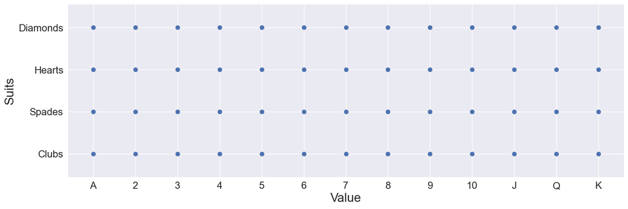

```python
plot_deck(group_by="cards", w=16, h=5)
```

- All these options seem reasonable.

### Meaningful groups in clustering

- In clustering, meaningful groups are dependent on the **application**.
- It usually helps if we have some prior knowledge about the data and the problem.
- This makes it hard for us to objectively measure the quality of a clustering algorithm (or think about "true" clusters).

### Common applications: Data exploration

Although there is no notion of the "right" answer, we might still get something useful out of clustering. There are a number of common applications for clustering.

- Summarize or compress data.
- Partition the data into groups before further processing.
- For instance, you could use it in supervised learning setting as follows. Carry out clustering and examine performance of your model on individual clusters. If the performance is lower on a particular cluster, you could either try building a separate model for that cluster and improve the overall performance of your supervised model.

### Common applications: Customer segmentation

- Understand landscape of the market in businesses and craft targeted business or marketing strategies tailored for each group.

[figure not shown]

[source](https://www.youtube.com/watch?v=zPJtDohab-g&t=134s)

### Document clustering

Grouping articles on different topics from different news sources. For example, [Google News](https://news.google.com).

[figure not shown]

### Similarity and distances

- Clustering is based on the notion of similarity or distances between points.
- How do we determine similarity between points in a multi-dimensional space?
- Can we use something like $k$-neighbours for similarity?
  - Yes! That's a good start!
  - With $k$-neighbours we used Euclidean distances to find nearby points.
  - We can use the same idea for clustering!

## K-Means clustering algorithm

### K-Means clustering

One of the most commonly used clustering algorithm.

**Input**

- `X` $\rightarrow$ a set of data points
- `K` (or $k$ or `n_clusters`) $\rightarrow$ number of clusters

**Output**

- `K` clusters (groups) of the data points

### K-Means using `sklearn`

- Before understanding the algorithm, let's try it with `sklearn`.
- Consider the toy dataset above.
- For this toy dataset, the three clusters are pretty clear.

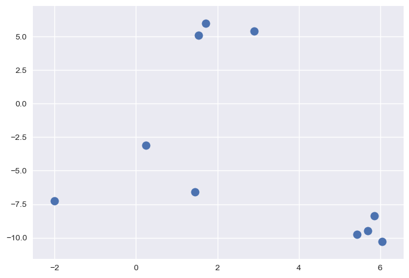

```python
X, y = make_blobs(n_samples=10, centers=3, n_features=2, random_state=10)
mglearn.discrete_scatter(X[:, 0], X[:, 1], markers="o");
```

```python
X
```

```
array([[  5.69192445,  -9.47641249],
       [  1.70789903,   6.00435173],
       [  0.23621041,  -3.11909976],
       [  2.90159483,   5.42121526],
       [  5.85943906,  -8.38192364],
       [  6.04774884, -10.30504657],
       [ -2.00758803,  -7.24743939],
       [  1.45467725,  -6.58387198],
       [  1.53636249,   5.11121453],
       [  5.4307043 ,  -9.75956122]])
```

```python
toy_df = pd.DataFrame(data=X, columns=["feat1", "feat2"])
toy_df
```

|  | feat1 | feat2 |
| --- | --- | --- |
| 0 | 5.691924 | -9.476412 |
| 1 | 1.707899 | 6.004352 |
| 2 | 0.236210 | -3.119100 |
| 3 | 2.901595 | 5.421215 |
| 4 | 5.859439 | -8.381924 |
| 5 | 6.047749 | -10.305047 |
| 6 | -2.007588 | -7.247439 |
| 7 | 1.454677 | -6.583872 |
| 8 | 1.536362 | 5.111215 |
| 9 | 5.430704 | -9.759561 |

### `KMeans` `fit`

Let's try `sklearn`'s `KMeans` algorithm on this dataset.

- We need to decide how many clusters we want. Here we are passing 3.
- We are only passing `X` because this is unsupervised learning; we do not have labels.

```python
from sklearn.cluster import KMeans

kmeans = KMeans(n_clusters=3)
kmeans.fit(X)
# We are only passing X because this is unsupervised learning
```

```
KMeans(n_clusters=3)
```

### `predict` of `KMeans`

- The output of `KMeans` is $K$ clusters (groups) of the data points.
- Calling `predict` will give us the cluster assignment for each data point.

```python
kmeans.predict(X)
```

```
array([1, 0, 2, 0, 1, 1, 2, 2, 0, 1])
```

```python
toy_df_cl = toy_df.copy()
toy_df_cl["cluster"] = kmeans.predict(toy_df)
toy_df_cl
```

|  | feat1 | feat2 | cluster |
| --- | --- | --- | --- |
| 0 | 5.691924 | -9.476412 | 1 |
| 1 | 1.707899 | 6.004352 | 0 |
| 2 | 0.236210 | -3.119100 | 2 |
| 3 | 2.901595 | 5.421215 | 0 |
| 4 | 5.859439 | -8.381924 | 1 |
| 5 | 6.047749 | -10.305047 | 1 |
| 6 | -2.007588 | -7.247439 | 2 |
| 7 | 1.454677 | -6.583872 | 2 |
| 8 | 1.536362 | 5.111215 | 0 |
| 9 | 5.430704 | -9.759561 | 1 |

### Cluster centers in K-Means

- In K-Means each cluster is represented by its cluster center.

```python
kmeans.cluster_centers_
```

```
array([[ 2.04861878,  5.51226051],
       [ 5.75745416, -9.48073598],
       [-0.10556679, -5.65013704]])
```

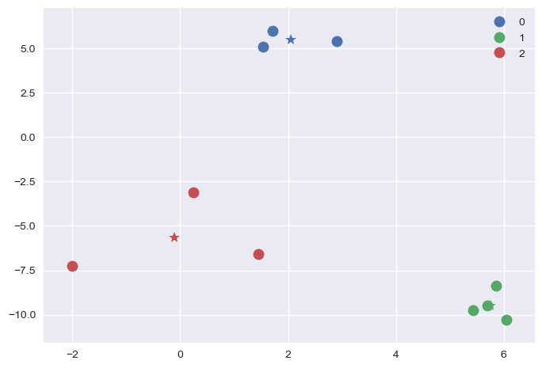

```python
mglearn.discrete_scatter(X[:, 0], X[:, 1], kmeans.labels_, markers="o")
plt.legend()
mglearn.discrete_scatter(
    kmeans.cluster_centers_[:, 0], kmeans.cluster_centers_[:, 1], [0, 1, 2], markers="*"
);
```

### K-Means predictions on new examples

- We can also use `predict` on unseen examples!

```python
new_examples = np.array([[-1, -5], [2, 5.0]])
kmeans.predict(new_examples)
```

```
array([2, 0])
```

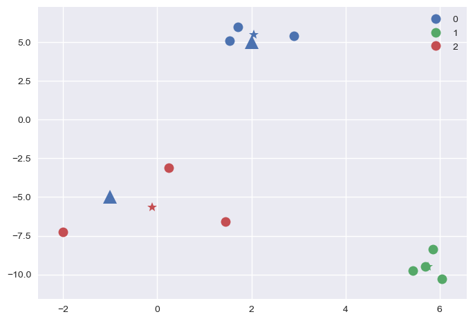

```python
mglearn.discrete_scatter(X[:, 0], X[:, 1], kmeans.labels_, markers="o")
plt.legend()
mglearn.discrete_scatter(new_examples[:, 0], new_examples[:, 1], markers="^", s=15)
mglearn.discrete_scatter(
    kmeans.cluster_centers_[:, 0], kmeans.cluster_centers_[:, 1], [0, 1, 2], markers="*"
);
```

### K-Means algorithm: Main idea

- Represent each cluster by its cluster center and assign a cluster membership to each data point.

**Chicken-and-egg problem!**

- If we knew cluster centers, we can simply assign each point to its nearest center.
- Similarly, if we knew assignments, we can calculate cluster centers.
- But we do not know either 😟.

A usual computer science answer to such problems is iterations!!

### K-Means clustering algorithm

**Input**: Data points X and the number of clusters K

**Initialization**: K initial centers for the clusters

**Iterative process**:

repeat

- Assign each example to the closest center.
- Estimate new centers as *average* of observations in a cluster.

until **centers stop changing** or **maximum iterations have reached**.

Let's execute K-Means algorithm on our toy example.

**Input**

- The data points `X`

```python
n_examples = toy_df.shape[0]
print("Number of examples: ", n_examples)
X
```

```
Number of examples:  10
```

```
array([[  5.69192445,  -9.47641249],
       [  1.70789903,   6.00435173],
       [  0.23621041,  -3.11909976],
       [  2.90159483,   5.42121526],
       [  5.85943906,  -8.38192364],
       [  6.04774884, -10.30504657],
       [ -2.00758803,  -7.24743939],
       [  1.45467725,  -6.58387198],
       [  1.53636249,   5.11121453],
       [  5.4307043 ,  -9.75956122]])
```

- Let K (number of clusters) be 3.

```python
k = 3
```

### Initialization

- Random initialization for K initial centers of the clusters.

```python
np.random.seed(seed=14)
centers_idx = np.random.choice(range(0, n_examples), size=k)
centers_df = toy_df.iloc[centers_idx]
centers = X[centers_idx]
colours = ["black", "blue", "red"]
```

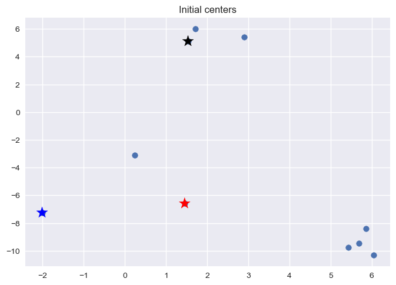

```python
plt.scatter(X[:, 0], X[:, 1], marker="o")
plt.scatter(centers[:, 0], centers[:, 1], c=colours, marker="*", s=200)
plt.title("Initial centers");
```

### Iterative process

repeat

- Assign each example to the closest center. (`update_Z`)
- Estimate new centers as *average* of observations in a cluster. (`update_centers`)

until **centers stop changing** or **maximum iterations have reached**.

### How to find closest centers?

- First step in the iterative process is assigning examples to the closest center.
- Let's consider distance of an example to all centers and assign that example to the closest center.

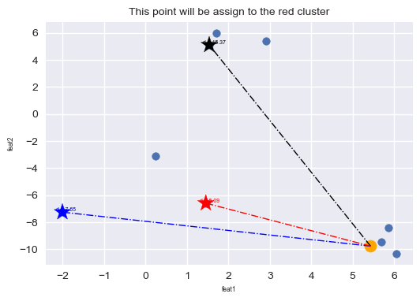

```python
plot_example_dist(toy_df, centers_df, 6, 4)
```

### How to find closest centers?

- Similarly, we can make cluster assignments for all points by calculating distances of all examples to the centers and assigning it to the cluster with smallest distance.

```python
from sklearn.metrics import euclidean_distances


def update_Z(X, centers):
    """
    returns distances and updated cluster assignments
    """
    dist = euclidean_distances(X, centers)
    return dist, np.argmin(dist, axis=1)
```

### How to update centers?

- With the new cluster assignments for our data points, we update cluster centers.
- New cluster centers are means of data points in each cluster.

```python
def update_centers(X, Z, old_centers, k):
    """
    returns new centers
    """
    new_centers = old_centers.copy()
    for kk in range(k):
        new_centers[kk] = np.mean(X[Z == kk], axis=0)
    return new_centers
```

### Iteration 1: Step 1

- Assign each example to the closest cluster center.

```python
dist, Z = update_Z(X, centers)
Z
```

```
array([2, 0, 2, 0, 2, 2, 1, 2, 0, 2], dtype=int64)
```

- This is the current cluster assignment.

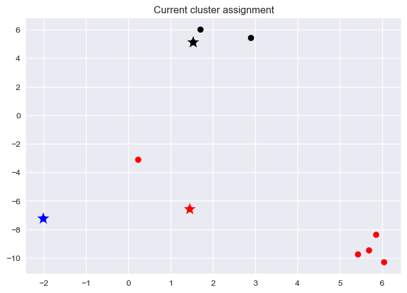

```python
plot_current_assinment(X, Z, centers)
```

### Iteration 1: Step 2

- Estimate new centers as *average* of observations in a cluster.

```python
new_centers_it1 = update_centers(X, Z, centers, k)
```

- This is how the centers moved in this iteration.

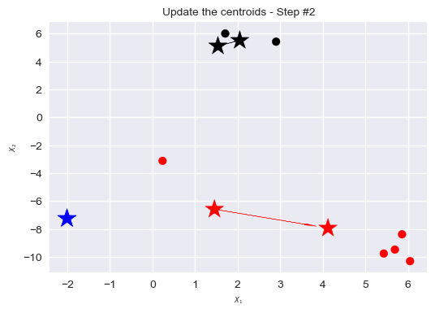

```python
plot_update_centroid(toy_df, new_centers_it1, centers, dist)
```

### Iteration 2: step 1

- Assign each example to the closest cluster center.

```python
dist, Z = update_Z(X, new_centers_it1)
Z
```

```
array([2, 0, 1, 0, 2, 2, 1, 2, 0, 2], dtype=int64)
```

- This is the current cluster assignment.

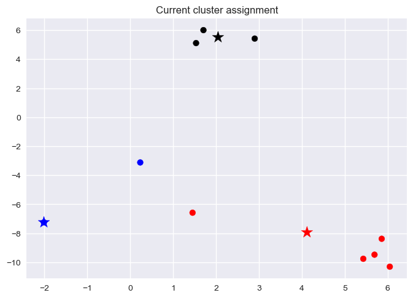

```python
plot_current_assinment(X, Z, new_centers_it1)
```

### Iteration 2: step 2

- Estimate new centers as *average* of observations in a cluster.

```python
new_centers_it2 = update_centers(X, Z, new_centers_it1, k)
```

- This is how the centers moved in this iteration.

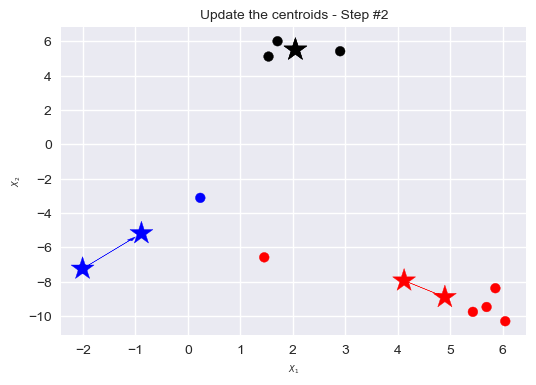

```python
plot_update_centroid(toy_df, new_centers_it2, new_centers_it1, dist)
```

### Iteration 3: step 1

- Assign each example to the closest cluster center.

```python
dist, Z = update_Z(X, new_centers_it2)
Z
```

```
array([2, 0, 1, 0, 2, 2, 1, 1, 0, 2], dtype=int64)
```

- This is the current cluster assignment.

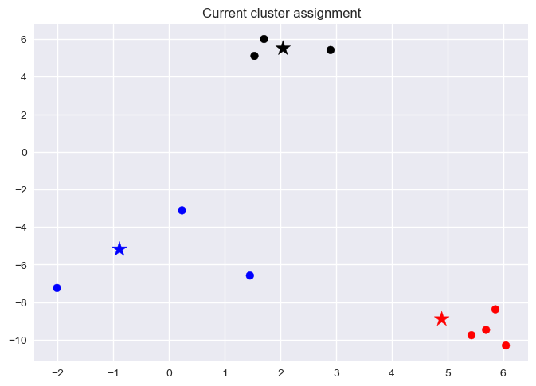

```python
plot_current_assinment(X, Z, new_centers_it2)
```

### Iteration 3: step 2

- Estimate new centers as *average* of observations in a cluster.

```python
new_centers_it3 = update_centers(X, Z, new_centers_it2, k)
```

- This is how the centers moved in this iteration.

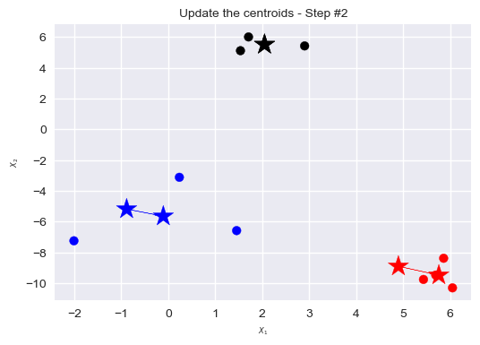

```python
plot_update_centroid(toy_df, new_centers_it3, new_centers_it2, dist)
```

### Iteration 4: step 1

- Assign each example to the closest cluster center.

```python
dist, Z = update_Z(X, new_centers_it3)
Z
```

```
array([2, 0, 1, 0, 2, 2, 1, 1, 0, 2], dtype=int64)
```

- This is the current cluster assignment.

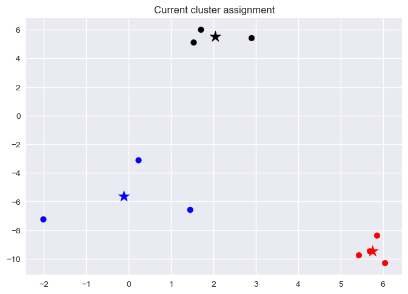

```python
plot_current_assinment(X, Z, new_centers_it3)
```

### Iteration 4: step 2

- Estimate new centers as *average* of observations in a cluster.

```python
new_centers_it4 = update_centers(X, Z, new_centers_it3, k)
```

- The cluster centers are not moving anymore.

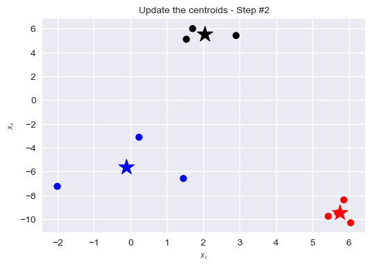

```python
plot_update_centroid(toy_df, new_centers_it4, new_centers_it3, dist)
```

### Iteration 5: step 1

- Assign each example to the closest cluster center.

```python
dist, Z = update_Z(X, new_centers_it4)
Z
```

```
array([2, 0, 1, 0, 2, 2, 1, 1, 0, 2], dtype=int64)
```

- This is the current cluster assignment.

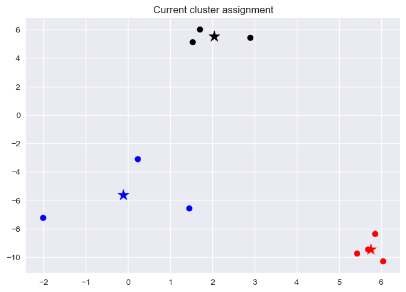

```python
plot_current_assinment(X, Z, new_centers_it4)
```

### Iteration 5: step 2

- Estimate new centers as *average* of observations in a cluster.

```python
new_centers_it5 = update_centers(X, Z, new_centers_it4, k)
```

- The cluster centers are not moving anymore.

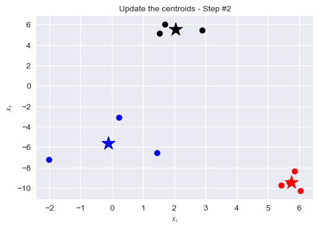

```python
plot_update_centroid(toy_df, new_centers_it5, new_centers_it4, dist)
```

### When to stop?

- Seems like our centroids aren't changing anymore.
- The algorithm has converged. So we stop!
- K-Means always converges. It doesn't mean it finds the "right" clusters. It can converge to a sub-optimal solution.

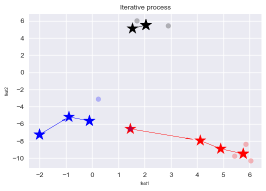

```python
plot_iterative(toy_df, centers)
```

Initialization is crucial. We'll talk about it in a bit.

## Choosing K

### Hyperparameter tuning for K

- K-Means takes K (`n_clusters` in `sklearn`) as a hyperparameter. How do we pick K?
- In supervised setting we carried out hyperparameter optimization based on cross-validation scores.
- Since in unsupervised learning we do not have the target values, it becomes difficult to objectively measure the effectiveness of the algorithms.
- There is no definitive approach.
- However, some strategies might be useful to help you determine K.

### Method 1: The Elbow method

- This method looks at the sum of **intra-cluster distances**, which is also referred to as **inertia**.
- The intra-cluster distance in our toy example above is given as

$$\sum_{P_i \in C_1} distance(P_i, C_1)^2 + \sum_{P_i \in C_2} distance(P_i, C_2)^2 + \sum_{P_i \in C_3} distance(P_i, C_3)^2$$

Where

- $C_1, C_2, C_3$ are centroids
- $P_i$s are points within that cluster
- $distance$ is the usual Euclidean distance.

### Inertia

You can access this intra-cluster distance or inertia as follows.

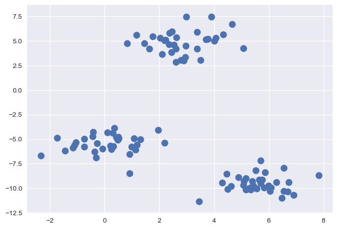

```python
X, y = make_blobs(centers=3, n_features=2, random_state=10)
mglearn.discrete_scatter(X[:, 0], X[:, 1], markers="o");
```

```python
d = {"K": [], "inertia": []}
for k in range(1, 100, 10):
    model = KMeans(n_clusters=k).fit(X)
    d["K"].append(k)
    d["inertia"].append(model.inertia_)
```

```python
pd.DataFrame(d)
```

|  | K | inertia |
| --- | --- | --- |
| 0 | 1 | 4372.460950 |
| 1 | 11 | 58.474524 |
| 2 | 21 | 26.900485 |
| 3 | 31 | 12.770892 |
| 4 | 41 | 6.421834 |
| 5 | 51 | 3.593682 |
| 6 | 61 | 1.961654 |
| 7 | 71 | 0.945421 |
| 8 | 81 | 0.322479 |
| 9 | 91 | 0.053156 |

- The inertia decreases as K increases.
- Question: Do we want inertia to be small or large?
- The problem is that we can't just look for a $k$ that minimizes inertia because it decreases as $k$ increases.
  - If I have number of clusters = number of examples, each example will have its own cluster and the intra-cluster distance will be 0.
- Instead we evaluate the trade-off: "small k" vs "small intra-cluster distances".

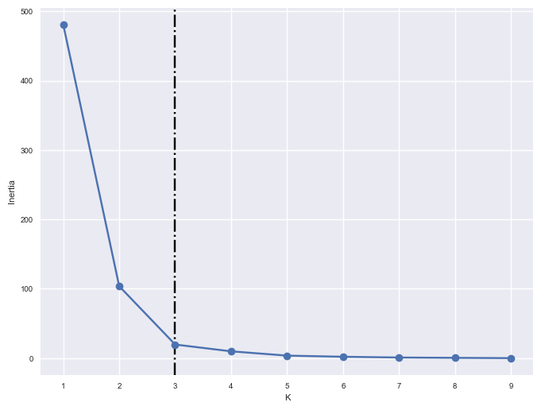

```python
inertia_values = list()
for k in range(1, 10):
    inertia_values.append(KMeans(n_clusters=k).fit(toy_df).inertia_)
plot_elbow(8, 6, inertia_values)
```

- From the above plot, we could argue that three clusters (the point of inflection on the curve) are enough.
- The inertia decreases when clusters are greater than 3. However it's not a big improvement and so we prefer K=3.
- In this toy example, it's the plot is kind of clear and easy to interpret but it can be hard to interpret in real life examples.

There is a package called [`yellowbrick`](https://www.scikit-yb.org/en/latest/api/cluster/elbow.html) which can be used to create these plots conveniently.

```
conda install -c districtdatalabs yellowbrick
```

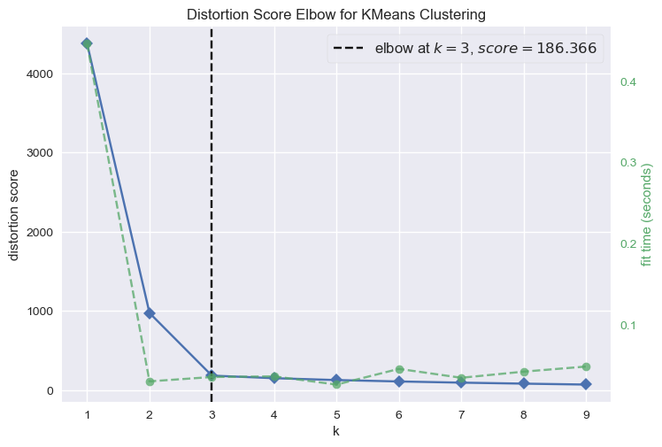

```python
from yellowbrick.cluster import KElbowVisualizer

model = KMeans()
visualizer = KElbowVisualizer(model, k=(1, 10))

visualizer.fit(X)  # Fit the data to the visualizer
visualizer.show();
```

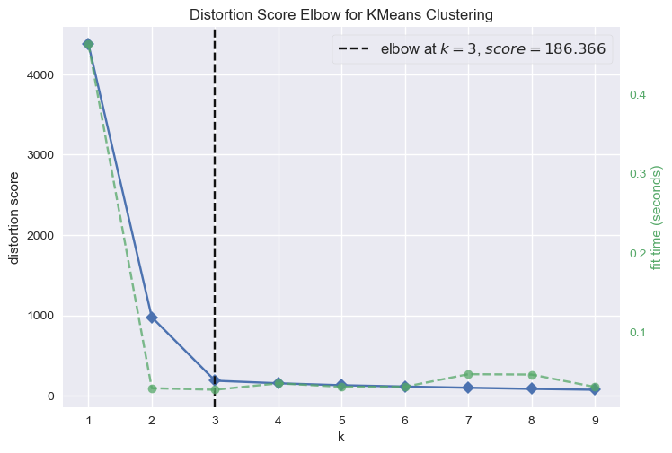

```python
visualizer = KElbowVisualizer(model, k=(1, 10))

visualizer.fit(X)  # Fit the data to the visualizer
visualizer.finalize();
```

```python
visualizer.draw()
```

### Method 2: The Silhouette method

- Not dependent on the notion of cluster centers.
- Calculated using the **mean intra-cluster distance** ($a$) and the **mean nearest-cluster distance** ($b$) for each sample.

### Mean intra-cluster distance ($a$)

- Suppose the green point below is our sample.
- Average of the distances of the green point to the other points in the same cluster.
  - These distances are represented by the black lines.

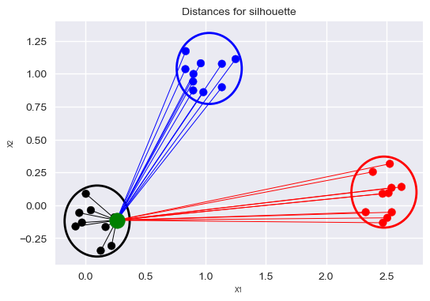

```python
plot_silhouette_dist(6, 4)
```

### Mean nearest-cluster distance ($b$)

- Average of the distances of the green point to the blue points is smaller than the average of the distances of the green point to the red points. So the **nearest cluster** is the blue cluster.
- So the mean nearest-cluster distance is the average of the distances of the green point to the blue points.

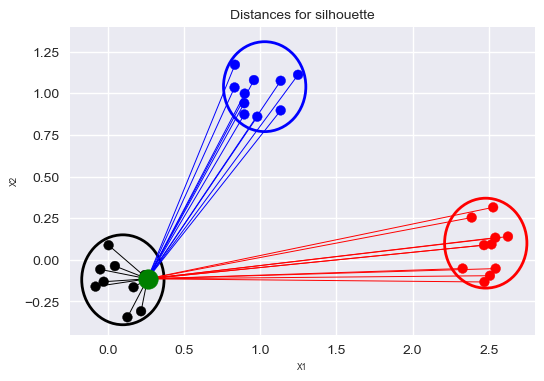

```python
plot_silhouette_dist(6, 4)
```

### Silhouette distance for a sample

- the difference between the **the average nearest-cluster distance** ($b$) and **average intra-cluster distance** ($a$) for each sample, normalized by the maximum value

$$\frac{b-a}{max(a,b)}$$

- The best value is 1.
- The worst value is -1 (samples have been assigned to wrong clusters).
- Value near 0 means overlapping clusters.

The overall **Silhouette score** is the average of the Silhouette scores for all samples.

### Using Silhouette scores to select the number of clusters

- The plots below show the Silhouette scores for each sample in that cluster.
- Higher values indicate well-separated clusters.
- The size of the Silhouette shows the number of samples and hence shows imbalance of data points in clusters.

```python
from yellowbrick.cluster import SilhouetteVisualizer
```

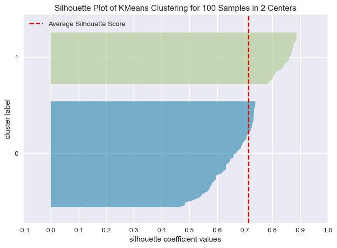

```python
model = KMeans(2, random_state=42)
visualizer = SilhouetteVisualizer(model, colors="yellowbrick")
visualizer.fit(X)  # Fit the data to the visualizer
visualizer.show();
# Finalize and render the figure
```

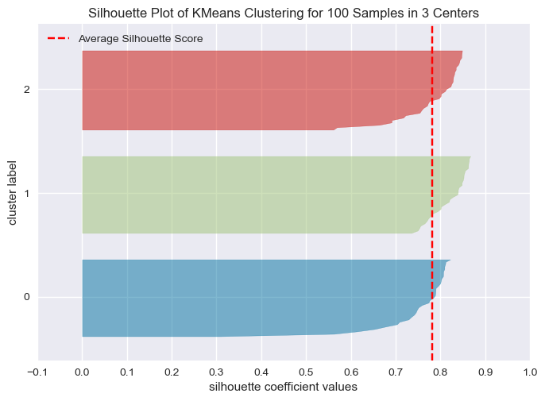

```python
model = KMeans(3, random_state=42)
visualizer = SilhouetteVisualizer(model, colors="yellowbrick")
visualizer.fit(X)  # Fit the data to the visualizer
visualizer.show();
# Finalize and render the figure
```

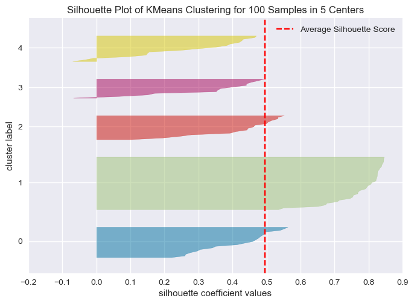

```python
model = KMeans(5, random_state=42)
visualizer = SilhouetteVisualizer(model, colors="yellowbrick")
visualizer.fit(X)  # Fit the data to the visualizer
visualizer.show();
# Finalize and render the figure
```

### What to look for in these plots?

- Unlike inertia, larger values are better because they indicate that the point is further away from neighbouring clusters.
- The thickness of each silhouette indicates the cluster size.
- The shape of each silhouette indicates the "goodness" for points in each cluster.
- The length (or area) of each silhouette indicates the goodness of each cluster.
- A slower dropoff (more rectangular) indicates more points are "happy" in their cluster.

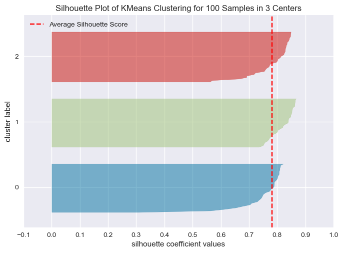

```python
model = KMeans(3, random_state=42)
visualizer = SilhouetteVisualizer(model, colors="yellowbrick")
visualizer.fit(X)  # Fit the data to the visualizer
visualizer.show();
# Finalize and render the figure
```

### ❓❓ Questions for you

**Select all of the following statements which are TRUE.**

- (A) K-Means may converge to different solutions depending upon the initialization.
- (B) K-means terminates when the number of clusters does not increase between iterations.
- (C) $K$ in K-Means should always be $\leq$ # of features.
- (D) In K-Means, it makes sense to have $K$ $\leq$ # of examples.
- (E) In K-Means, in some iterations some points may be left unassigned.

**Select all of the following statements which are TRUE.**

- (A) K-Means is sensitive to initialization and the solution may change depending upon the initialization.
- (B) K-means terminates when the number of clusters does not increase between iterations.
- (C) K-means terminates when the centroid locations do not change between iterations.
- (D) If you train K-Means with `n_clusters`= the number of examples, the inertia value will be 0.
- (E) Unlike the Elbow method, the Silhouette method is not dependent on the notion of cluster centers.

## K-Means case study: Customer segmentation

### What is customer segmentation?

- Understand landscape of the market in businesses and craft targeted business or marketing strategies tailored for each group.

[figure not shown]

[source](https://www.youtube.com/watch?v=zPJtDohab-g&t=134s)

Check out [this interesting talk by Malcom Gladwell](https://www.ted.com/talks/malcolm_gladwell_on_spaghetti_sauce?language=en). Humans are diverse and there is no single spaghetti sauce that would make all of them happy!

Often it's beneficial to businesses to explore the landscape of the market and tailor their services and products offered to each group. This is called **customer segmentation**. It's usually applied when the dataset contains some of the following features.

- **Demographic information** such as gender, age, marital status, income, education, and occupation
- **Geographical information** such as specific towns or counties or a customer's city, state, or even country of residence (in case of big global companies)
- **Psychographics** such as social class, lifestyle, and personality traits
- **Behavioral data** such as spending and consumption habits, product/service usage, and desired benefits

### Business problem

- Imagine that you are hired as a data scientist at a bank. They provide some data of their credit card customers to you.
- Their goal is to develop customized marketing campaigns and they ask you to group customers based on the given information.
- Now that you know about K-Means clustering, let's apply it to the dataset to group customers.

### Data

- We will use the [Credit Card Dataset for clustering](https://www.kaggle.com/arjunbhasin2013/ccdata) from Kaggle.
- Download the data and save the CSV under the `data` folder.
- I encourage you to work through this case study on your own.

```python
creditcard_df = pd.read_csv("data/CC General.csv")
creditcard_df.shape
```

```
(8950, 18)
```

### Information of the dataset

We have behavioral data.

- CUSTID: Identification of Credit Card holder
- BALANCE: Balance amount left in customer's account to make purchases
- BALANCE_FREQUENCY: How frequently the Balance is updated, score between 0 and 1 (1 = frequently updated, 0 = not frequently updated)
- PURCHASES: Amount of purchases made from account
- ONEOFFPURCHASES: Maximum purchase amount done in one-go
- INSTALLMENTS_PURCHASES: Amount of purchase done in installment
- CASH_ADVANCE: Cash in advance given by the user
- PURCHASES_FREQUENCY: How frequently the Purchases are being made, score between 0 and 1 (1 = frequently purchased, 0 = not frequently purchased)
- ONEOFF_PURCHASES_FREQUENCY: How frequently Purchases are happening in one-go (1 = frequently purchased, 0 = not frequently purchased)
- PURCHASES_INSTALLMENTS_FREQUENCY: How frequently purchases in installments are being done (1 = frequently done, 0 = not frequently done)
- CASH_ADVANCE_FREQUENCY: How frequently the cash in advance being paid
- CASH_ADVANCE_TRX: Number of Transactions made with "Cash in Advance"
- PURCHASES_TRX: Number of purchase transactions made
- CREDIT_LIMIT: Limit of Credit Card for user
- PAYMENTS: Amount of Payment done by user
- MINIMUM_PAYMENTS: Minimum amount of payments made by user
- PRC_FULL_PAYMENT: Percent of full payment paid by user
- TENURE: Tenure of credit card service for user

### Preliminary EDA

```python
creditcard_df.info()
```

```
<class 'pandas.core.frame.DataFrame'>
RangeIndex: 8950 entries, 0 to 8949
Data columns (total 18 columns):
 #   Column                            Non-Null Count  Dtype
---  ------                            --------------  -----
 0   CUST_ID                           8950 non-null   object
 1   BALANCE                           8950 non-null   float64
 2   BALANCE_FREQUENCY                 8950 non-null   float64
 3   PURCHASES                         8950 non-null   float64
 4   ONEOFF_PURCHASES                  8950 non-null   float64
 5   INSTALLMENTS_PURCHASES            8950 non-null   float64
 6   CASH_ADVANCE                      8950 non-null   float64
 7   PURCHASES_FREQUENCY               8950 non-null   float64
 8   ONEOFF_PURCHASES_FREQUENCY        8950 non-null   float64
 9   PURCHASES_INSTALLMENTS_FREQUENCY  8950 non-null   float64
 10  CASH_ADVANCE_FREQUENCY            8950 non-null   float64
 11  CASH_ADVANCE_TRX                  8950 non-null   int64
 12  PURCHASES_TRX                     8950 non-null   int64
 13  CREDIT_LIMIT                      8949 non-null   float64
 14  PAYMENTS                          8950 non-null   float64
 15  MINIMUM_PAYMENTS                  8637 non-null   float64
 16  PRC_FULL_PAYMENT                  8950 non-null   float64
 17  TENURE                            8950 non-null   int64
dtypes: float64(14), int64(3), object(1)
memory usage: 1.2+ MB
```

- All numeric features
- Some missing values

```python
creditcard_df.describe()
```

|  | BALANCE | BALANCE_FREQUENCY | PURCHASES | ONEOFF_PURCHASES | INSTALLMENTS_PURCHASES | CASH_ADVANCE | PURCHASES_FREQUENCY | ONEOFF_PURCHASES_FREQUENCY | PURCHASES_INSTALLMENTS_FREQUENCY | CASH_ADVANCE_FREQUENCY | CASH_ADVANCE_TRX | PURCHASES_TRX | CREDIT_LIMIT | PAYMENTS | MINIMUM_PAYMENTS | PRC_FULL_PAYMENT | TENURE |
| --- | --- | --- | --- | --- | --- | --- | --- | --- | --- | --- | --- | --- | --- | --- | --- | --- | --- |
| count | 8950.000000 | 8950.000000 | 8950.000000 | 8950.000000 | 8950.000000 | 8950.000000 | 8950.000000 | 8950.000000 | 8950.000000 | 8950.000000 | 8950.000000 | 8950.000000 | 8949.000000 | 8950.000000 | 8637.000000 | 8950.000000 | 8950.000000 |
| mean | 1564.474828 | 0.877271 | 1003.204834 | 592.437371 | 411.067645 | 978.871112 | 0.490351 | 0.202458 | 0.364437 | 0.135144 | 3.248827 | 14.709832 | 4494.449450 | 1733.143852 | 864.206542 | 0.153715 | 11.517318 |
| std | 2081.531879 | 0.236904 | 2136.634782 | 1659.887917 | 904.338115 | 2097.163877 | 0.401371 | 0.298336 | 0.397448 | 0.200121 | 6.824647 | 24.857649 | 3638.815725 | 2895.063757 | 2372.446607 | 0.292499 | 1.338331 |
| min | 0.000000 | 0.000000 | 0.000000 | 0.000000 | 0.000000 | 0.000000 | 0.000000 | 0.000000 | 0.000000 | 0.000000 | 0.000000 | 0.000000 | 50.000000 | 0.000000 | 0.019163 | 0.000000 | 6.000000 |
| 25% | 128.281915 | 0.888889 | 39.635000 | 0.000000 | 0.000000 | 0.000000 | 0.083333 | 0.000000 | 0.000000 | 0.000000 | 0.000000 | 1.000000 | 1600.000000 | 383.276166 | 169.123707 | 0.000000 | 12.000000 |
| 50% | 873.385231 | 1.000000 | 361.280000 | 38.000000 | 89.000000 | 0.000000 | 0.500000 | 0.083333 | 0.166667 | 0.000000 | 0.000000 | 7.000000 | 3000.000000 | 856.901546 | 312.343947 | 0.000000 | 12.000000 |
| 75% | 2054.140036 | 1.000000 | 1110.130000 | 577.405000 | 468.637500 | 1113.821139 | 0.916667 | 0.300000 | 0.750000 | 0.222222 | 4.000000 | 17.000000 | 6500.000000 | 1901.134317 | 825.485459 | 0.142857 | 12.000000 |
| max | 19043.138560 | 1.000000 | 49039.570000 | 40761.250000 | 22500.000000 | 47137.211760 | 1.000000 | 1.000000 | 1.000000 | 1.500000 | 123.000000 | 358.000000 | 30000.000000 | 50721.483360 | 76406.207520 | 1.000000 | 12.000000 |

```python
# Answer 3.
max_cash_advance = creditcard_df["CASH_ADVANCE"].max()
creditcard_df[creditcard_df["CASH_ADVANCE"] == max_cash_advance]
```

|  | CUST_ID | BALANCE | BALANCE_FREQUENCY | PURCHASES | ONEOFF_PURCHASES | INSTALLMENTS_PURCHASES | CASH_ADVANCE | PURCHASES_FREQUENCY | ONEOFF_PURCHASES_FREQUENCY | PURCHASES_INSTALLMENTS_FREQUENCY | CASH_ADVANCE_FREQUENCY | CASH_ADVANCE_TRX | PURCHASES_TRX | CREDIT_LIMIT | PAYMENTS | MINIMUM_PAYMENTS | PRC_FULL_PAYMENT | TENURE |
| --- | --- | --- | --- | --- | --- | --- | --- | --- | --- | --- | --- | --- | --- | --- | --- | --- | --- | --- |
| 2159 | C12226 | 10905.05381 | 1.0 | 431.93 | 133.5 | 298.43 | 47137.21176 | 0.583333 | 0.25 | 0.5 | 1.0 | 123 | 21 | 19600.0 | 39048.59762 | 5394.173671 | 0.0 | 12 |

Let's examine correlations between features.

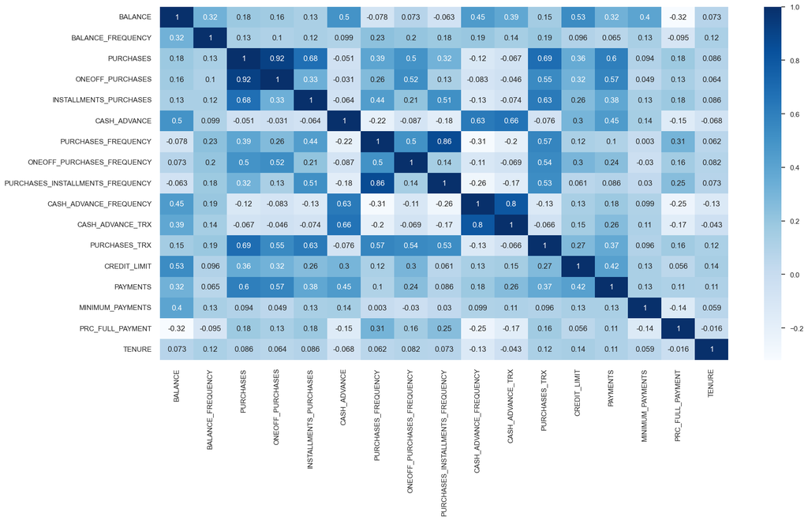

```python
cor = creditcard_df.corr()
plt.figure(figsize=(20, 10))
sns.set(font_scale=1)
sns.heatmap(cor, annot=True, cmap=plt.cm.Blues);
```

### Feature types and preprocessing

Let's identify different feature types and transformations

```python
creditcard_df.columns
```

```
Index(['CUST_ID', 'BALANCE', 'BALANCE_FREQUENCY', 'PURCHASES',
       'ONEOFF_PURCHASES', 'INSTALLMENTS_PURCHASES', 'CASH_ADVANCE',
       'PURCHASES_FREQUENCY', 'ONEOFF_PURCHASES_FREQUENCY',
       'PURCHASES_INSTALLMENTS_FREQUENCY', 'CASH_ADVANCE_FREQUENCY',
       'CASH_ADVANCE_TRX', 'PURCHASES_TRX', 'CREDIT_LIMIT', 'PAYMENTS',
       'MINIMUM_PAYMENTS', 'PRC_FULL_PAYMENT', 'TENURE'],
      dtype='object')
```

```python
drop_features = ["CUST_ID"]
numeric_features = list(set(creditcard_df.columns) - set(drop_features))
```

```python
from sklearn.impute import SimpleImputer

numeric_transformer = make_pipeline(SimpleImputer(), StandardScaler())

preprocessor = make_column_transformer(
    (numeric_transformer, numeric_features), ("drop", drop_features)
)
```

```python
transformed_df = pd.DataFrame(
    data=preprocessor.fit_transform(creditcard_df), columns=numeric_features
)
```

```python
transformed_df
```

|  | ONEOFF_PURCHASES | BALANCE_FREQUENCY | PAYMENTS | CASH_ADVANCE | CREDIT_LIMIT | PURCHASES | PRC_FULL_PAYMENT | MINIMUM_PAYMENTS | PURCHASES_TRX | PURCHASES_INSTALLMENTS_FREQUENCY | TENURE | PURCHASES_FREQUENCY | CASH_ADVANCE_FREQUENCY | CASH_ADVANCE_TRX | INSTALLMENTS_PURCHASES | BALANCE | ONEOFF_PURCHASES_FREQUENCY |
| --- | --- | --- | --- | --- | --- | --- | --- | --- | --- | --- | --- | --- | --- | --- | --- | --- | --- |
| 0 | -0.356934 | -0.249434 | -0.528979 | -0.466786 | -0.960433 | -0.424900 | -0.525551 | -3.109675e-01 | -0.511333 | -0.707313 | 0.360680 | -0.806490 | -0.675349 | -0.476070 | -0.349079 | -0.731989 | -0.678661 |
| 1 | -0.356934 | 0.134325 | 0.818642 | 2.605605 | 0.688639 | -0.469552 | 0.234227 | 8.931021e-02 | -0.591796 | -0.916995 | 0.360680 | -1.221758 | 0.573963 | 0.110074 | -0.454576 | 0.786961 | -0.678661 |
| 2 | 0.108889 | 0.518084 | -0.383805 | -0.466786 | 0.826062 | -0.107668 | -0.525551 | -1.016632e-01 | -0.109020 | -0.916995 | 0.360680 | 1.269843 | -0.675349 | -0.476070 | -0.454576 | 0.447135 | 2.673451 |
| 3 | 0.546189 | -1.016953 | -0.598688 | -0.368653 | 0.826062 | 0.232058 | -0.525551 | 4.878305e-17 | -0.551565 | -0.916995 | 0.360680 | -1.014125 | -0.258913 | -0.329534 | -0.454576 | 0.049099 | -0.399319 |
| 4 | -0.347294 | 0.518084 | -0.364368 | -0.466786 | -0.905464 | -0.462063 | -0.525551 | -2.657913e-01 | -0.551565 | -0.916995 | 0.360680 | -1.014125 | -0.675349 | -0.476070 | -0.454576 | -0.358775 | -0.399319 |
| ... | ... | ... | ... | ... | ... | ... | ... | ... | ... | ... | ... | ... | ... | ... | ... | ... | ... |
| 8945 | -0.356934 | 0.518084 | -0.486217 | -0.466786 | -0.960433 | -0.333293 | 1.183951 | -3.498541e-01 | -0.350408 | 1.179833 | -4.122768 | 1.269843 | -0.675349 | -0.476070 | -0.132643 | -0.737950 | -0.678661 |
| 8946 | -0.356934 | 0.518084 | -0.503396 | -0.466786 | -0.960433 | -0.329136 | -0.525551 | 4.878305e-17 | -0.350408 | 1.179833 | -4.122768 | 1.269843 | -0.675349 | -0.476070 | -0.122823 | -0.742423 | -0.678661 |
| 8947 | -0.356934 | -0.185477 | -0.570615 | -0.466786 | -0.960433 | -0.401965 | 0.329200 | -3.354655e-01 | -0.390639 | 0.760469 | -4.122768 | 0.854576 | -0.675349 | -0.476070 | -0.294893 | -0.740398 | -0.678661 |
| 8948 | -0.356934 | -0.185477 | -0.580536 | -0.449352 | -1.097856 | -0.469552 | 0.329200 | -3.469065e-01 | -0.591796 | -0.916995 | -4.122768 | -1.221758 | 0.157527 | -0.182998 | -0.454576 | -0.745174 | -0.678661 |
| 8949 | 0.301732 | -0.889033 | -0.576869 | -0.406205 | -0.905464 | 0.042146 | -0.525551 | -3.329464e-01 | 0.333524 | -0.916995 | -4.122768 | 0.439310 | 0.990398 | -0.182998 | -0.454576 | -0.572575 | 1.556082 |

8950 rows × 17 columns

Now that we have transformed the data, we are ready to run K-Means to cluster credit card customers.

### Choosing `n_clusters`

- There is no definitive method to find the optimal number of clusters.
- Let's try different approaches.